# in situ vignette: data checking and calibration

Christina Bonsell

April 17, 2020

```r
library(insitu)
```

This package was developed to streamline QA/QC of hydrographic (CTD and current) timeseries data from the Arctic coast of Alaska within the R environment. Specifically, functions in this package calibrate data and flag suspicious data either programatically or manually. Many of the functions within have general use for QA/QC of hydrographic timeseries regardless of location.

For example: Calculate salinity from conductivty and temperature ising the UNESCO algorithm

```r
calculate_salinity(25.50,1)
```

```
## [1] 29.37815
```

Easily read in files from either RBR or starOddi CTDs, or Lowell Tilt Current Meters via `import_data`

## How to Perform quality control on CTD datasets, with particular focus on Arctic nearshore systems

The remainder of this vignette demonstrates a typical workflow for QA/QC of such datasets.

First let’s load in some handy packages

```r
library(RCurl) #For loading in data directly from online repositories
library(tidyverse) #we're going to work in the tidyverse for data manipulation and plotting
library(cowplot)
```

Read in some data (this is Beaufort Lagoon Ecosystem LTER data from 2018-2019)

```r
urlCSV <- getURL("https://portal-s.edirepository.org/nis/dataviewer?packageid=knb-lter-ble.3.7&entityid=534373640a661d8ed0bfedc52479a133", timeout = 200)
txtCSV <- textConnection(urlCSV)
tempsal_data <- read.csv(txtCSV, stringsAsFactors = F) %>%
  filter(station=="KALD1") %>%
  mutate(date_time=as.POSIXct(date_time, format="%m/%d/%Y %H:%M"))
close(txtCSV)

head(tempsal_data)
```

```
##   station           date_time temperature salinity conductivity sound_vel
## 1   KALD1 2018-08-07 16:00:00        5.51    32.81        32.00   1469.87
## 2   KALD1 2018-08-07 17:00:00        5.22    33.42        32.28   1469.48
## 3   KALD1 2018-08-07 18:00:00        5.15    32.68        31.58   1468.23
## 4   KALD1 2018-08-07 19:00:00        5.00    24.53        24.23   1457.12
## 5   KALD1 2018-08-07 20:00:00        4.93    17.57        17.82   1447.84
## 6   KALD1 2018-08-07 21:00:00        4.74    16.75        16.97   1446.01
```

```r
str(tempsal_data)
```

```
## 'data.frame':    8839 obs. of  6 variables:
##  $ station     : chr  "KALD1" "KALD1" "KALD1" "KALD1" ...
##  $ date_time   : POSIXct, format: "2018-08-07 16:00:00" "2018-08-07 17:00:00" ...
##  $ temperature : num  5.51 5.22 5.15 5 4.93 4.74 4.96 5.07 5.47 5.33 ...
##  $ salinity    : num  32.8 33.4 32.7 24.5 17.6 ...
##  $ conductivity: num  32 32.3 31.6 24.2 17.8 ...
##  $ sound_vel   : num  1470 1469 1468 1457 1448 ...
```

Simple timeseries plots

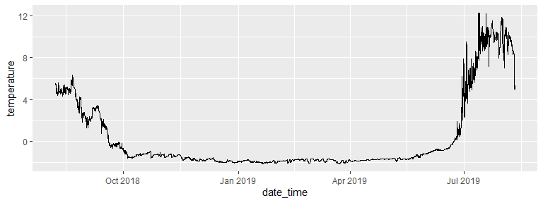

```r
ggplot(tempsal_data, aes(date_time, temperature))+
  geom_line()
```

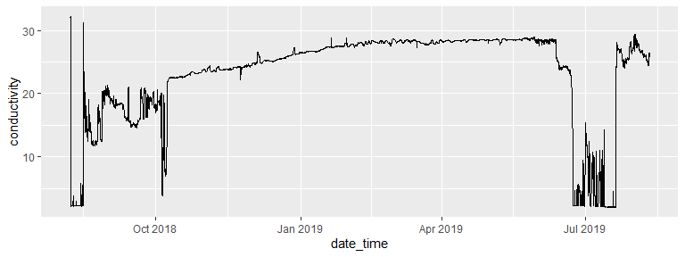

```r
ggplot(tempsal_data, aes(date_time, conductivity))+
  geom_line()
```

Some of this conductivity data is clearly bad (look at that June-July weirdness)! We need to calibrate the data and remove “bad” points.

### Calibrate the data based on readings from a more recently-calibrated sensor

Read in data from YSI sonde measurements after deployment and just before retrieval of the CTD

```r
urlCSV <- getURL("https://portal-s.edirepository.org/nis/dataviewer?packageid=knb-lter-ble.3.7&entityid=6d327300d4893e4f932220fecf49c507", timeout = 200)
txtCSV <- textConnection(urlCSV)
ysi<- read.csv(txtCSV, stringsAsFactors = F) %>%
  filter(station=="KALD1") %>%
  mutate(date_time=as.POSIXct(substr(date_time,1, 16), format="%Y-%m-%dT%H:%M"))#datetime is in ISO 8601, but inports as character
close(txtCSV)

head(ysi)
```

```
##   station           date_time salinity temperature_C conductivity_uS_cm
## 1   KALD1 2019-04-28 12:00:00    39.33          -1.8             30.540
## 2   KALD1 2019-08-08 10:00:00    25.93           9.1             28.391
```

Calibrate the data based on linear relationship between these two “anchor” points. Note that this will also work with >2 anchor points, for which the adjustment will be based on the linear relationship between each sequential pair of anchor points. If data exists before or after anchor points, the linear relationship will use the first (in the before case), or last (in the after case) reading from the raw data.

```r
tempsal_data_calibrated <- calibrate_data(tempsal_data, ysi, raw= "temperature", cal_by = "temperature_C")
```

```
## KALD1 station:
##  Found 2 calibration point(s) from YSI data at: 2019-04-28 15:00:00, 2019-08-08 13:00:00
```

```
##  Using first row of raw instrument data at 2018-08-07 16:00:00 as calibration point.
```

```
##  Using last row of raw instrument data at NA as calibration point.
```

```r
tempsal_data_calibrated  <- calibrate_data(tempsal_data_calibrated, ysi, raw= "conductivity", cal_by = "conductivity_uS_cm")
```

```
## KALD1 station:
##  Found 2 calibration point(s) from YSI data at: 2019-04-28 15:00:00, 2019-08-08 13:00:00
```

```
##  Using first row of raw instrument data at 2018-08-07 16:00:00 as calibration point.
```

```
##  Using last row of raw instrument data at NA as calibration point.
```

```r
head(tempsal_data_calibrated)
```

```
##   station           date_time temperature salinity conductivity sound_vel
## 1   KALD1 2018-08-07 16:00:00        5.51    32.81        32.00   1469.87
## 2   KALD1 2018-08-07 17:00:00        5.22    33.42        32.28   1469.48
## 3   KALD1 2018-08-07 18:00:00        5.15    32.68        31.58   1468.23
## 4   KALD1 2018-08-07 19:00:00        5.00    24.53        24.23   1457.12
## 5   KALD1 2018-08-07 20:00:00        4.93    17.57        17.82   1447.84
## 6   KALD1 2018-08-07 21:00:00        4.74    16.75        16.97   1446.01
##   temperature_c temperature_calibrated conductivity_us_cm
## 1            NA               5.510000                 NA
## 2            NA               5.219991                 NA
## 3            NA               5.149981                 NA
## 4            NA               4.999972                 NA
## 5            NA               4.929962                 NA
## 6            NA               4.739953                 NA
##   conductivity_calibrated
## 1                32.00000
## 2                32.28033
## 3                31.58067
## 4                24.23100
## 5                17.82133
## 6                16.97167
```

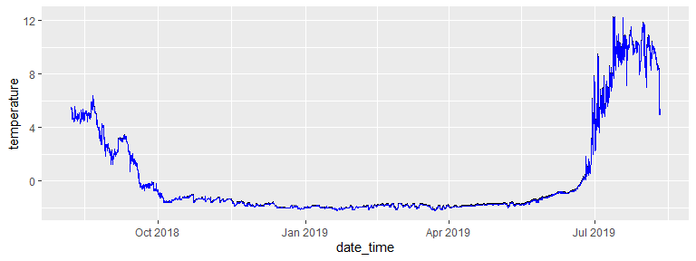

```r
ggplot(tempsal_data_calibrated, aes(date_time, temperature))+
  geom_line()+
  geom_line(aes(date_time, temperature_calibrated), color="blue")
```

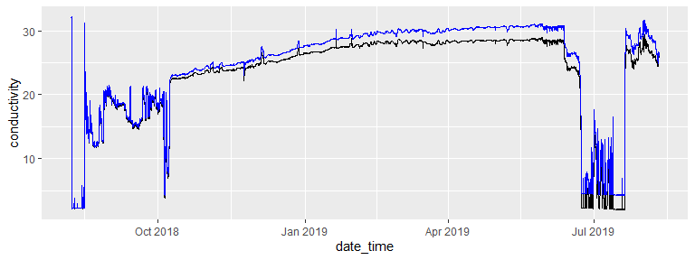

```r
ggplot(tempsal_data_calibrated, aes(date_time, conductivity))+
  geom_line()+
  geom_line(aes(date_time, conductivity_calibrated), color="blue")
```

Ok, now that the data is calibrated, let’s calculate and plot salinity. We’re going to to this the “tidyverse” way

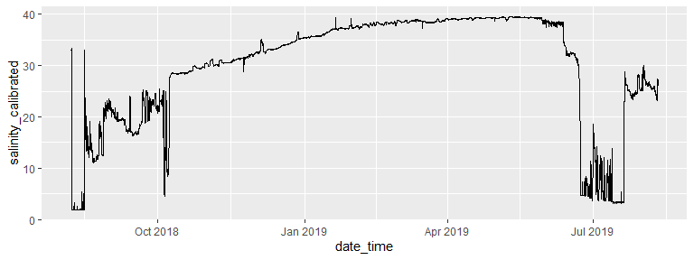

```r
tempsal_data_calibrated <- tempsal_data_calibrated %>%
  mutate(salinity_calibrated=calculate_salinity(conductivity_calibrated, temperature_calibrated))

ggplot(tempsal_data_calibrated, aes(date_time, salinity_calibrated))+
  geom_line()
```

Clearly some of that data is still bad, so let’s flag it…

### Identify “bad” data based on the freezing line from temperature/salinity plots

Temperature/salinity plots can easily tell you when something is amiss in your data. This often occurs because the conductivity reading if off due to obstruction by sediments or fouling (for instruments with a conductivity cup), or by nearby ice or other conductive materials (for RBR “donuts”). In cold regions, data below the freezing line is expecially suspect.

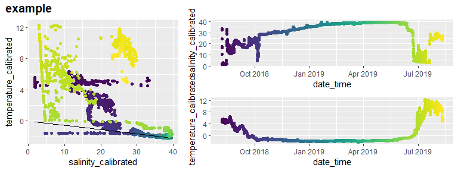

```r
plot_tempsal(tempsal_data_calibrated, "temperature_calibrated", "salinity_calibrated", "date_time", plottitle="example")
```

The straight lines for points in the temp vs sal plot indicate intstrument error. We can flag the points below the freezing line programatically. This function creates a column `anomalous` to indicated flagged data

```r
tempsal_data_flagged <- flag_salinity(tempsal_data_calibrated, tempcol="temperature_calibrated", condcol="conductivity_calibrated",Terror=.1, Cerror = 2, flag_scheme = c("VALID","INV"))

head(tempsal_data_flagged)
```

```
##   station           date_time temperature salinity conductivity sound_vel
## 1   KALD1 2018-08-07 16:00:00        5.51    32.81        32.00   1469.87
## 2   KALD1 2018-08-07 17:00:00        5.22    33.42        32.28   1469.48
## 3   KALD1 2018-08-07 18:00:00        5.15    32.68        31.58   1468.23
## 4   KALD1 2018-08-07 19:00:00        5.00    24.53        24.23   1457.12
## 5   KALD1 2018-08-07 20:00:00        4.93    17.57        17.82   1447.84
## 6   KALD1 2018-08-07 21:00:00        4.74    16.75        16.97   1446.01
##   temperature_c temperature_calibrated conductivity_us_cm
## 1            NA               5.510000                 NA
## 2            NA               5.219991                 NA
## 3            NA               5.149981                 NA
## 4            NA               4.999972                 NA
## 5            NA               4.929962                 NA
## 6            NA               4.739953                 NA
##   conductivity_calibrated salinity_calibrated anomalous
## 1                32.00000            32.82421     VALID
## 2                32.28033            33.43120     VALID
## 3                31.58067            32.69799     VALID
## 4                24.23100            24.53269     VALID
## 5                17.82133            17.57637     VALID
## 6                16.97167            16.76237     VALID
```

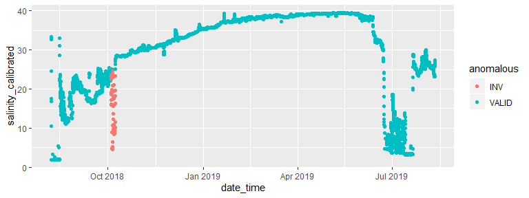

```r
ggplot(tempsal_data_flagged, aes(date_time, salinity_calibrated))+
  geom_point(aes(color=anomalous))
```

Clearly, this doesn’t take care of all the suspicous data.

### Easily manually identify “bad” data that doesn’t get picked up from the freezing line algorithm

This function will open up an external window where you can manually click on suspicious points. Click “Stop” in the upper left of the pop-up when you are done.

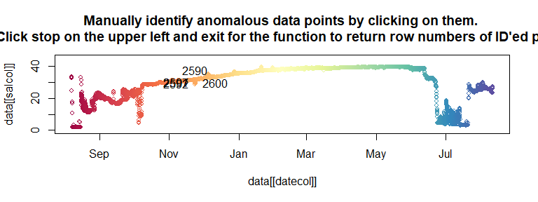

```
## [1] 2590 2591 2592 2597 2600
```

```r
bad_points <- id_outlier(tempsal_data_calibrated, datecol="date_time", tempcol="temperature_calibrated", salcol="salinity_calibrated")

bad_points
```

Note that you can incorporate this output into the flag column of your dataframe via indexing

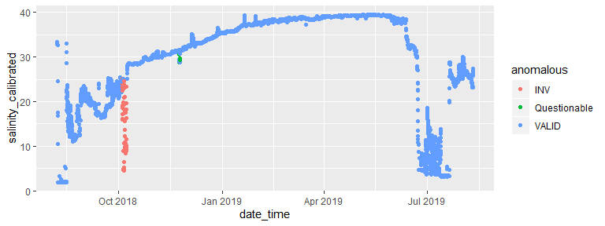

```r
tempsal_data_flagged$anomalous[bad_points] <- "Questionable"

ggplot(tempsal_data_flagged, aes(date_time, salinity_calibrated))+
  geom_point(aes(color=anomalous))
```